# Traditional Credit Model

Created by: Emiliano Mena Gonzalez

Repository: https://github.com/EmilianoMena/Credit_Model

## Introduction

On this project the main objective is to create a Credit Model that gives three posible scores (Poor, Standard or Good) to a list of different people contained on the train.csv database file. This file it already includes a score for each case and the goal is to achieve the highest accuracy possible to this given model. The database has 100,000 rows (each row represents a person with all kind of information). To make the model firs is necessary to select the information it matters based on the FICO model.

The FICO model is a punctuation system that goes from 300 to 850 points, it was created on the 1950s and in 1989 the first version was released, since that year they been the most used system in the United States and a lot of other countries. Before anything else let´s first see the database in order to select the variables we will need.

```python
# Libraries and dependencies
import data as d
import functions as f
import main as m
import visualizations as v
```

```python
d.train.head()
```

|  | ID | Customer_ID | Month | Name | Age | SSN | Occupation | Annual_Income | Monthly_Inhand_Salary | Num_Bank_Accounts | ... | Credit_Mix | Outstanding_Debt | Credit_Utilization_Ratio | Credit_History_Age | Payment_of_Min_Amount | Total_EMI_per_month | Amount_invested_monthly | Payment_Behaviour | Monthly_Balance | Credit_Score |
| --- | --- | --- | --- | --- | --- | --- | --- | --- | --- | --- | --- | --- | --- | --- | --- | --- | --- | --- | --- | --- | --- |
| 0 | 5634 | 3392 | 1 | Aaron Maashoh | 23.0 | 821000265.0 | Scientist | 19114.12 | 1824.843333 | 3.0 | ... | Good | 809.98 | 26.822620 | 265.0 | No | 49.574949 | 21.46538 | High_spent_Small_value_payments | 312.494089 | Good |
| 1 | 5635 | 3392 | 2 | Aaron Maashoh | 23.0 | 821000265.0 | Scientist | 19114.12 | 1824.843333 | 3.0 | ... | Good | 809.98 | 31.944960 | 266.0 | No | 49.574949 | 21.46538 | Low_spent_Large_value_payments | 284.629162 | Good |
| 2 | 5636 | 3392 | 3 | Aaron Maashoh | 23.0 | 821000265.0 | Scientist | 19114.12 | 1824.843333 | 3.0 | ... | Good | 809.98 | 28.609352 | 267.0 | No | 49.574949 | 21.46538 | Low_spent_Medium_value_payments | 331.209863 | Good |
| 3 | 5637 | 3392 | 4 | Aaron Maashoh | 23.0 | 821000265.0 | Scientist | 19114.12 | 1824.843333 | 3.0 | ... | Good | 809.98 | 31.377862 | 268.0 | No | 49.574949 | 21.46538 | Low_spent_Small_value_payments | 223.451310 | Good |
| 4 | 5638 | 3392 | 5 | Aaron Maashoh | 23.0 | 821000265.0 | Scientist | 19114.12 | 1824.843333 | 3.0 | ... | Good | 809.98 | 24.797347 | 269.0 | No | 49.574949 | 21.46538 | High_spent_Medium_value_payments | 341.489231 | Good |

5 rows × 28 columns

## Model

The variables that we will pick are going to be the ones that are part of the five pillars of the FICO model. This pillars are:

1. Payment history
2. Amount debt
3. Credit history
4. New credit requests
5. Types of credit

So now we have a little table that contains the variables selected and the pillar they are part of, including also the percentage it will have on the final score.

| FICO | Own model | % of final score |
| --- | --- | --- |
| Payment history | Delay_from_due_date & Num_of_Delayed_Payment | 35% |
| Amount debt | Outstanding_Debt | 30% |
| Credit history | Credit_History_Age | 10% |
| New credit requests | Credit_Mix | 15% |
| Types of credit | Num_Credit_Inquiries | 10% |

The model is based on punctuation system that goes from 175 to 1000. The final score of every person is:

- Poor: if the total of points it gets is under 600.
- Standard: this score has to get minimum of 600 points and less than 800.
- Good: to achieve this score is necessary to get 800 points or more.

```python
m.df.head(10)
```

|  | Score Points | Model Score | Original Score |
| --- | --- | --- | --- |
| 0 | 850 | Good | Good |
| 1 | 900 | Good | Good |
| 2 | 850 | Good | Good |
| 3 | 850 | Good | Good |
| 4 | 850 | Good | Good |
| 5 | 850 | Good | Good |
| 6 | 850 | Good | Good |
| 7 | 850 | Good | Standard |
| 8 | 925 | Good | Standard |
| 9 | 925 | Good | Good |

We can see on the table the points and score that the model gave and the comparison with the original score they had on the database. On this first cases almost all the scores where the same of the model and the given on the database, only two received a Good score and they had originally a Standard score.

```python
print('The accuracy of the model was of',round(m.accuracy,2),'%.')
```

```
The accuracy of the model was of 63.97 %.
```

```
<sklearn.metrics._plot.confusion_matrix.ConfusionMatrixDisplay at 0x1e0becee410>
```

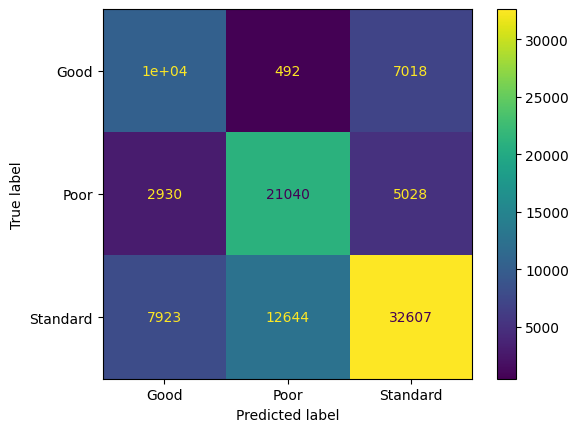

```python
v.cm_display.plot()
```

Finally on the confusion matrix we can see that the most errors are the Poor-Standard they where Standard but the model marked them as Poor. The Standard scores where the ones that the model fit best to the original scores with 32,607.

## Conclusions

The model has a good accuracy considering that is based on five pillars of a traditional model that is based on the past information and doesn´t consider anything of machine learning or something similar. Maybe to upgrade the accuracy it could be considered other information as the salary or the credit ratio utilization to optimize the score and maybe improve the score of the people they have more salary and use more credit and still pay on time.